# Five-minute variable distributions

Author

Alessandro Fuschi

## Setup

```r
library(tidyverse)
cfg <- list(
  data_dir = file.path("data", "5min"),
  analysis_start_date = as.Date("2025-03-01"),
  timezone = "UTC",
  histogram_bins = 60,
  lower_display_quantile = 0.01,
  upper_display_quantile = 0.99
)

theme_set(theme_minimal(base_size = 12))
```

## Aim

Distributions use one bucket mean per participant and variable at five-minute resolution.

`step_mean` and `cal_mean` average repeated readings rather than summing them. Technical fields, counts and extrema are excluded as separate variables.

Coordinates are excluded to protect locations; GPS accuracy is retained. Sleep-state counts are shown separately.

No additional validity filter is applied. Histograms display the 1st–99th percentiles for readability; summaries retain the full range.

## Variable definitions

```r
variable_metadata <- tribble(
  ~data_stream, ~source_variable, ~variable, ~unit,
  "GPS", "accuracy_mean", "GPS accuracy", "m",
  "Environment", "pm1_mean", "PM1", "µg/m³",
  "Environment", "pm25_mean", "PM2.5", "µg/m³",
  "Environment", "pm10_mean", "PM10", "µg/m³",
  "Environment", "pc03_mean", "Particles ≥0.3 µm", "sensor count",
  "Environment", "pc05_mean", "Particles ≥0.5 µm", "sensor count",
  "Environment", "pc1_mean", "Particles ≥1.0 µm", "sensor count",
  "Environment", "pc25_mean", "Particles ≥2.5 µm", "sensor count",
  "Environment", "pc5_mean", "Particles ≥5.0 µm", "sensor count",
  "Environment", "pc10_mean", "Particles ≥10 µm", "sensor count",
  "Environment", "temperature_mean", "Air temperature", "°C",
  "Environment", "humidity_mean", "Relative humidity", "%",
  "Environment", "pressure_mean", "Air pressure", "hPa",
  "Environment", "sound_mean", "Sound", "sensor units",
  "Environment", "uvb_mean", "UVB", "sensor units",
  "Environment", "light_mean", "Light", "sensor units",
  "Smartwatch high frequency", "heartrate_mean", "Heart rate", "bpm",
  "Smartwatch high frequency", "oxygens_mean", "Oxygen saturation", "%",
  "Smartwatch high frequency", "breathrate_mean", "Breathing rate", "breaths/min",
  "Smartwatch low frequency", "step_mean", "Steps", "steps/5 min",
  "Smartwatch low frequency", "cal_mean", "Calories", "sensor units",
  "Smartwatch low frequency", "bphigh_mean", "Systolic blood pressure", "mmHg",
  "Smartwatch low frequency", "bplow_mean", "Diastolic blood pressure", "mmHg",
  "Smartwatch low frequency", "bodytemp_mean", "bodytemp", "sensor units",
  "Smartwatch low frequency", "skintemp_mean", "skintemp", "sensor units"
)

stream_levels <- c("GPS", "Environment", "Smartwatch high frequency", "Smartwatch low frequency")
```

Particle counts are cumulative above each size threshold; physical normalization is undocumented. Sensor-unit labels preserve unresolved scales.

## Data preparation

Study window: `2025-03-01 < date < Sys.Date()` (UTC).

### GPS accuracy

```r
gps_variables <- variable_metadata %>% filter(data_stream == "GPS") %>% pull(source_variable)

if (!exists("gps_5min", inherits = FALSE)) {
  gps_5min <- read_csv(
    file.path(cfg$data_dir, "gps_5min.csv.gz"),
    col_types = cols(userId = col_character(), bucket_5min = col_datetime(), deviceId = col_character(), firmware = col_character()),
    locale = locale(tz = "UTC"), na = c("", "NA", "NULL"), show_col_types = FALSE
  )
}
gps <- gps_5min %>% select(userId, bucket_5min, all_of(gps_variables))
gps <- gps %>%
  filter(
    as.Date(bucket_5min, tz = cfg$timezone) > cfg$analysis_start_date,
    as.Date(bucket_5min, tz = cfg$timezone) < Sys.Date()
  )


gps_results <- map(gps_variables, \(variable_name) {
  values <- gps[[variable_name]]
  observed <- is.finite(values)
  finite_values <- values[observed]

  if (length(finite_values) == 0) {
    return(list(
      summary = tibble(
        source_variable = variable_name, participants = 0L, observed_5min_buckets = 0L,
        missing_or_non_finite_percent = 100, zero_percent = NA_real_, minimum = NA_real_,
        p01 = NA_real_, p25 = NA_real_, median = NA_real_, p75 = NA_real_, p99 = NA_real_, maximum = NA_real_
      ),
      histogram = tibble()
    ))
  }

  quantiles <- quantile(finite_values, c(0.01, 0.25, 0.5, 0.75, 0.99), names = FALSE)
  display_limits <- quantile(
    finite_values, c(cfg$lower_display_quantile, cfg$upper_display_quantile), names = FALSE
  )
  central_values <- finite_values[finite_values >= display_limits[1] & finite_values <= display_limits[2]]
  breaks <- if (display_limits[1] == display_limits[2]) {
    display_limits + c(-0.5, 0.5)
  } else {
    seq(display_limits[1], display_limits[2], length.out = cfg$histogram_bins + 1)
  }
  histogram <- hist(central_values, breaks = breaks, plot = FALSE, include.lowest = TRUE)

  list(
    summary = tibble(
      source_variable = variable_name,
      participants = n_distinct(gps$userId[observed]),
      observed_5min_buckets = length(finite_values),
      missing_or_non_finite_percent = 100 * mean(!observed),
      zero_percent = 100 * mean(finite_values == 0),
      minimum = min(finite_values), p01 = quantiles[1], p25 = quantiles[2],
      median = quantiles[3], p75 = quantiles[4], p99 = quantiles[5], maximum = max(finite_values)
    ),
    histogram = tibble(
      source_variable = variable_name,
      bin_midpoint = histogram$mids,
      buckets = histogram$counts
    )
  )
})

gps_summary <- bind_rows(map(gps_results, "summary"))
gps_histograms <- bind_rows(map(gps_results, "histogram"))
rm(gps, gps_results)
invisible(gc())
```

### Environmental measurements

```r
air_variables <- variable_metadata %>% filter(data_stream == "Environment") %>% pull(source_variable)

if (!exists("myair_5min", inherits = FALSE)) {
  myair_5min <- read_csv(
    file.path(cfg$data_dir, "myair_5min.csv.gz"),
    col_types = cols(userId = col_character(), bucket_5min = col_datetime(), deviceId = col_character(), firmware = col_character()),
    locale = locale(tz = "UTC"), na = c("", "NA", "NULL"), show_col_types = FALSE
  )
}
air <- myair_5min %>% select(userId, bucket_5min, all_of(air_variables))
air <- air %>%
  filter(
    as.Date(bucket_5min, tz = cfg$timezone) > cfg$analysis_start_date,
    as.Date(bucket_5min, tz = cfg$timezone) < Sys.Date()
  )


air_results <- map(air_variables, \(variable_name) {
  values <- air[[variable_name]]
  observed <- is.finite(values)
  finite_values <- values[observed]

  if (length(finite_values) == 0) {
    return(list(
      summary = tibble(
        source_variable = variable_name, participants = 0L, observed_5min_buckets = 0L,
        missing_or_non_finite_percent = 100, zero_percent = NA_real_, minimum = NA_real_,
        p01 = NA_real_, p25 = NA_real_, median = NA_real_, p75 = NA_real_, p99 = NA_real_, maximum = NA_real_
      ),
      histogram = tibble()
    ))
  }

  quantiles <- quantile(finite_values, c(0.01, 0.25, 0.5, 0.75, 0.99), names = FALSE)
  display_limits <- quantile(
    finite_values, c(cfg$lower_display_quantile, cfg$upper_display_quantile), names = FALSE
  )
  central_values <- finite_values[finite_values >= display_limits[1] & finite_values <= display_limits[2]]
  breaks <- if (display_limits[1] == display_limits[2]) {
    display_limits + c(-0.5, 0.5)
  } else {
    seq(display_limits[1], display_limits[2], length.out = cfg$histogram_bins + 1)
  }
  histogram <- hist(central_values, breaks = breaks, plot = FALSE, include.lowest = TRUE)

  list(
    summary = tibble(
      source_variable = variable_name,
      participants = n_distinct(air$userId[observed]),
      observed_5min_buckets = length(finite_values),
      missing_or_non_finite_percent = 100 * mean(!observed),
      zero_percent = 100 * mean(finite_values == 0),
      minimum = min(finite_values), p01 = quantiles[1], p25 = quantiles[2],
      median = quantiles[3], p75 = quantiles[4], p99 = quantiles[5], maximum = max(finite_values)
    ),
    histogram = tibble(
      source_variable = variable_name,
      bin_midpoint = histogram$mids,
      buckets = histogram$counts
    )
  )
})

air_summary <- bind_rows(map(air_results, "summary"))
air_histograms <- bind_rows(map(air_results, "histogram"))
rm(air, air_results)
invisible(gc())
```

### High-frequency smartwatch measurements

```r
smartwatch_high_variables <- variable_metadata %>%
  filter(data_stream == "Smartwatch high frequency") %>%
  pull(source_variable)

if (!exists("smartwatchhigh_5min", inherits = FALSE)) {
  smartwatchhigh_5min <- read_csv(
    file.path(cfg$data_dir, "smartwatchhigh_5min.csv.gz"),
    col_types = cols(userId = col_character(), bucket_5min = col_datetime(), deviceId = col_character(), firmware = col_character()),
    locale = locale(tz = "UTC"), na = c("", "NA", "NULL"), show_col_types = FALSE
  )
}
smartwatch_high <- smartwatchhigh_5min %>%
  select(
    userId, bucket_5min, all_of(smartwatch_high_variables), sleeprate_0_n, sleeprate_1_n,
    sleeprate_2_n, sleeprate_3_n, sleeprate_4_n
  )
smartwatch_high <- smartwatch_high %>%
  filter(
    as.Date(bucket_5min, tz = cfg$timezone) > cfg$analysis_start_date,
    as.Date(bucket_5min, tz = cfg$timezone) < Sys.Date()
  )


smartwatch_high_results <- map(smartwatch_high_variables, \(variable_name) {
  values <- smartwatch_high[[variable_name]]
  observed <- is.finite(values)
  finite_values <- values[observed]

  if (length(finite_values) == 0) {
    return(list(
      summary = tibble(
        source_variable = variable_name, participants = 0L, observed_5min_buckets = 0L,
        missing_or_non_finite_percent = 100, zero_percent = NA_real_, minimum = NA_real_,
        p01 = NA_real_, p25 = NA_real_, median = NA_real_, p75 = NA_real_, p99 = NA_real_, maximum = NA_real_
      ),
      histogram = tibble()
    ))
  }

  quantiles <- quantile(finite_values, c(0.01, 0.25, 0.5, 0.75, 0.99), names = FALSE)
  display_limits <- quantile(
    finite_values, c(cfg$lower_display_quantile, cfg$upper_display_quantile), names = FALSE
  )
  central_values <- finite_values[finite_values >= display_limits[1] & finite_values <= display_limits[2]]
  breaks <- if (display_limits[1] == display_limits[2]) {
    display_limits + c(-0.5, 0.5)
  } else {
    seq(display_limits[1], display_limits[2], length.out = cfg$histogram_bins + 1)
  }
  histogram <- hist(central_values, breaks = breaks, plot = FALSE, include.lowest = TRUE)

  list(
    summary = tibble(
      source_variable = variable_name,
      participants = n_distinct(smartwatch_high$userId[observed]),
      observed_5min_buckets = length(finite_values),
      missing_or_non_finite_percent = 100 * mean(!observed),
      zero_percent = 100 * mean(finite_values == 0),
      minimum = min(finite_values), p01 = quantiles[1], p25 = quantiles[2],
      median = quantiles[3], p75 = quantiles[4], p99 = quantiles[5], maximum = max(finite_values)
    ),
    histogram = tibble(
      source_variable = variable_name,
      bin_midpoint = histogram$mids,
      buckets = histogram$counts
    )
  )
})

smartwatch_high_summary <- bind_rows(map(smartwatch_high_results, "summary"))
smartwatch_high_histograms <- bind_rows(map(smartwatch_high_results, "histogram"))

sleep_state_flags <- smartwatch_high %>%
  transmute(across(sleeprate_0_n:sleeprate_4_n, ~ replace_na(.x, 0) > 0))
sleep_buckets_with_state <- sum(rowSums(sleep_state_flags) > 0)
sleep_buckets_with_multiple_states <- sum(rowSums(sleep_state_flags) > 1)
sleep_state_summary <- sleep_state_flags %>%
  summarise(across(everything(), sum)) %>%
  pivot_longer(everything(), names_to = "state", values_to = "observed_5min_buckets") %>%
  mutate(
    state = recode(
      state, sleeprate_0_n = "State 0", sleeprate_1_n = "State 1", sleeprate_2_n = "State 2",
      sleeprate_3_n = "State 3", sleeprate_4_n = "State 4"
    ),
    percent_of_buckets_with_sleep_state = 100 * observed_5min_buckets / sleep_buckets_with_state
  )

rm(smartwatch_high, smartwatch_high_results, sleep_state_flags)
invisible(gc())
```

### Low-frequency smartwatch measurements

```r
smartwatch_low_variables <- variable_metadata %>%
  filter(data_stream == "Smartwatch low frequency") %>%
  pull(source_variable)

if (!exists("smartwatchlow_5min", inherits = FALSE)) {
  smartwatchlow_5min <- read_csv(
    file.path(cfg$data_dir, "smartwatchlow_5min.csv.gz"),
    col_types = cols(userId = col_character(), bucket_5min = col_datetime(), deviceId = col_character(), firmware = col_character()),
    locale = locale(tz = "UTC"), na = c("", "NA", "NULL"), show_col_types = FALSE
  )
}
smartwatch_low <- smartwatchlow_5min %>% select(userId, bucket_5min, all_of(smartwatch_low_variables))
smartwatch_low <- smartwatch_low %>%
  filter(
    as.Date(bucket_5min, tz = cfg$timezone) > cfg$analysis_start_date,
    as.Date(bucket_5min, tz = cfg$timezone) < Sys.Date()
  )


smartwatch_low_results <- map(smartwatch_low_variables, \(variable_name) {
  values <- smartwatch_low[[variable_name]]
  observed <- is.finite(values)
  finite_values <- values[observed]

  if (length(finite_values) == 0) {
    return(list(
      summary = tibble(
        source_variable = variable_name, participants = 0L, observed_5min_buckets = 0L,
        missing_or_non_finite_percent = 100, zero_percent = NA_real_, minimum = NA_real_,
        p01 = NA_real_, p25 = NA_real_, median = NA_real_, p75 = NA_real_, p99 = NA_real_, maximum = NA_real_
      ),
      histogram = tibble()
    ))
  }

  quantiles <- quantile(finite_values, c(0.01, 0.25, 0.5, 0.75, 0.99), names = FALSE)
  display_limits <- quantile(
    finite_values, c(cfg$lower_display_quantile, cfg$upper_display_quantile), names = FALSE
  )
  central_values <- finite_values[finite_values >= display_limits[1] & finite_values <= display_limits[2]]
  breaks <- if (display_limits[1] == display_limits[2]) {
    display_limits + c(-0.5, 0.5)
  } else {
    seq(display_limits[1], display_limits[2], length.out = cfg$histogram_bins + 1)
  }
  histogram <- hist(central_values, breaks = breaks, plot = FALSE, include.lowest = TRUE)

  list(
    summary = tibble(
      source_variable = variable_name,
      participants = n_distinct(smartwatch_low$userId[observed]),
      observed_5min_buckets = length(finite_values),
      missing_or_non_finite_percent = 100 * mean(!observed),
      zero_percent = 100 * mean(finite_values == 0),
      minimum = min(finite_values), p01 = quantiles[1], p25 = quantiles[2],
      median = quantiles[3], p75 = quantiles[4], p99 = quantiles[5], maximum = max(finite_values)
    ),
    histogram = tibble(
      source_variable = variable_name,
      bin_midpoint = histogram$mids,
      buckets = histogram$counts
    )
  )
})

smartwatch_low_summary <- bind_rows(map(smartwatch_low_results, "summary"))
smartwatch_low_histograms <- bind_rows(map(smartwatch_low_results, "histogram"))
rm(smartwatch_low, smartwatch_low_results)
invisible(gc())
```

## Distribution summary

Observed buckets count finite values. Missing/non-finite percentages use all retained source rows; pooled histograms give more influence to participants with more buckets.

```r
continuous_summary <- bind_rows(
  gps_summary, air_summary, smartwatch_high_summary, smartwatch_low_summary
) %>%
  left_join(variable_metadata, by = "source_variable", relationship = "many-to-one") %>%
  mutate(data_stream = factor(data_stream, levels = stream_levels)) %>%
  arrange(data_stream, match(source_variable, variable_metadata$source_variable))

distribution_histograms <- bind_rows(
  gps_histograms, air_histograms, smartwatch_high_histograms, smartwatch_low_histograms
) %>%
  left_join(variable_metadata, by = "source_variable", relationship = "many-to-one") %>%
  mutate(
    data_stream = factor(data_stream, levels = stream_levels),
    panel_label = factor(
      paste0(variable, " (", unit, ")"),
      levels = paste0(variable_metadata$variable, " (", variable_metadata$unit, ")")
    )
  )

rm(
  gps_summary, air_summary, smartwatch_high_summary, smartwatch_low_summary,
  gps_histograms, air_histograms, smartwatch_high_histograms, smartwatch_low_histograms
)
```

```r
continuous_summary %>%
  transmute(
    `Data stream` = data_stream, Variable = variable, Unit = unit,
    Participants = scales::label_number(big.mark = ",", accuracy = 1)(participants),
    `Observed buckets` = scales::label_number(big.mark = ",", accuracy = 1)(observed_5min_buckets),
    `Missing/non-finite (%)` = round(missing_or_non_finite_percent, 1),
    `Zero (%)` = round(zero_percent, 1),
    Minimum = scales::label_number(big.mark = ",", accuracy = 0.01)(minimum),
    P01 = scales::label_number(big.mark = ",", accuracy = 0.01)(p01),
    P25 = scales::label_number(big.mark = ",", accuracy = 0.01)(p25),
    Median = scales::label_number(big.mark = ",", accuracy = 0.01)(median),
    P75 = scales::label_number(big.mark = ",", accuracy = 0.01)(p75),
    P99 = scales::label_number(big.mark = ",", accuracy = 0.01)(p99),
    Maximum = scales::label_number(big.mark = ",", accuracy = 0.01)(maximum)
  ) %>%
  knitr::kable(
    format = "pipe",
    caption = "Coverage, zero frequency and full-range distribution summary by variable"
  )
```

Coverage, zero frequency and full-range distribution summary by variable

| Data stream | Variable | Unit | Participants | Observed buckets | Missing/non-finite (%) | Zero (%) | Minimum | P01 | P25 | Median | P75 | P99 | Maximum |
| --- | --- | --- | --- | --- | --- | --- | --- | --- | --- | --- | --- | --- | --- |
| GPS | GPS accuracy | m | 131 | 341,234 | 12.7 | 0.0 | 1.00 | 3.00 | 21.00 | 100.00 | 100.00 | 2,000.00 | 63,201.00 |
| Environment | PM1 | µg/m³ | 187 | 1,352,278 | 0.0 | 20.2 | 0.00 | 0.00 | 0.40 | 2.80 | 7.20 | 85.60 | 8,225.60 |
| Environment | PM2.5 | µg/m³ | 187 | 1,352,278 | 0.0 | 17.0 | 0.00 | 0.00 | 0.60 | 3.80 | 9.80 | 150.80 | 65,278.00 |
| Environment | PM10 | µg/m³ | 187 | 1,352,278 | 0.0 | 13.9 | 0.00 | 0.00 | 1.00 | 4.40 | 10.80 | 164.60 | 49,344.00 |
| Environment | Particles ≥0.3 µm | sensor count | 187 | 1,352,113 | 0.0 | 3.3 | 0.00 | 0.00 | 267.00 | 680.40 | 1,381.00 | 14,758.15 | 65,526.00 |
| Environment | Particles ≥0.5 µm | sensor count | 187 | 1,352,278 | 0.0 | 3.5 | 0.00 | 0.00 | 70.60 | 185.80 | 382.20 | 4,263.05 | 65,408.00 |
| Environment | Particles ≥1.0 µm | sensor count | 187 | 1,352,278 | 0.0 | 5.9 | 0.00 | 0.00 | 6.00 | 22.40 | 61.20 | 1,059.80 | 65,528.00 |
| Environment | Particles ≥2.5 µm | sensor count | 187 | 1,352,278 | 0.0 | 13.7 | 0.00 | 0.00 | 0.60 | 2.00 | 5.60 | 113.60 | 46,592.00 |
| Environment | Particles ≥5.0 µm | sensor count | 187 | 1,352,278 | 0.0 | 28.0 | 0.00 | 0.00 | 0.00 | 0.40 | 1.20 | 19.20 | 65,276.00 |
| Environment | Particles ≥10 µm | sensor count | 187 | 1,352,278 | 0.0 | 52.3 | 0.00 | 0.00 | 0.00 | 0.00 | 0.40 | 7.60 | 64,512.00 |
| Environment | Air temperature | °C | 187 | 1,352,278 | 0.0 | 0.0 | -2.18 | 17.46 | 23.56 | 26.19 | 29.43 | 35.97 | 52.88 |
| Environment | Relative humidity | % | 187 | 1,352,278 | 0.0 | 0.0 | 8.36 | 20.97 | 32.44 | 37.00 | 41.73 | 55.47 | 100.00 |
| Environment | Air pressure | hPa | 187 | 1,352,278 | 0.0 | 0.0 | 542.00 | 911.60 | 963.00 | 973.00 | 1,006.40 | 1,023.00 | 1,032.80 |
| Environment | Sound | sensor units | 187 | 1,352,278 | 0.0 | 0.0 | 32.20 | 39.60 | 44.60 | 47.20 | 52.00 | 78.40 | 108.40 |
| Environment | UVB | sensor units | 187 | 1,352,278 | 0.0 | 96.5 | 0.00 | 0.00 | 0.00 | 0.00 | 0.00 | 3.60 | 146.40 |
| Environment | Light | sensor units | 187 | 1,352,278 | 0.0 | 0.4 | 0.00 | 2.00 | 8.00 | 13.00 | 71.20 | 4,039.85 | 18,905.00 |
| Smartwatch high frequency | Heart rate | bpm | 203 | 3,230,953 | 0.1 | 0.0 | 42.00 | 47.20 | 62.80 | 73.00 | 85.00 | 110.60 | 188.00 |
| Smartwatch high frequency | Oxygen saturation | % | 187 | 794,981 | 75.4 | 0.0 | 91.00 | 95.40 | 97.00 | 97.00 | 97.20 | 99.00 | 99.00 |
| Smartwatch high frequency | Breathing rate | breaths/min | 124 | 1,821,195 | 43.7 | 0.0 | 4.00 | 8.60 | 13.60 | 15.80 | 17.80 | 38.40 | 50.00 |
| Smartwatch low frequency | Steps | steps/5 min | 207 | 4,447,372 | 0.0 | 76.1 | 0.00 | 0.00 | 0.00 | 0.00 | 0.00 | 434.00 | 925.00 |
| Smartwatch low frequency | Calories | sensor units | 207 | 4,447,372 | 0.0 | 78.7 | 0.00 | 0.00 | 0.00 | 0.00 | 0.00 | 22.00 | 836.00 |
| Smartwatch low frequency | Systolic blood pressure | mmHg | 203 | 3,217,598 | 27.7 | 0.0 | 107.00 | 112.00 | 116.00 | 120.00 | 123.00 | 128.00 | 133.00 |
| Smartwatch low frequency | Diastolic blood pressure | mmHg | 203 | 3,217,598 | 27.7 | 0.0 | 67.00 | 73.00 | 77.00 | 79.00 | 83.00 | 89.00 | 93.00 |
| Smartwatch low frequency | bodytemp | sensor units | 207 | 4,447,372 | 0.0 | 28.5 | 0.00 | 0.00 | 0.00 | 7.34 | 31.00 | 35.00 | 141.50 |
| Smartwatch low frequency | skintemp | sensor units | 207 | 4,447,372 | 0.0 | 28.5 | 0.00 | 0.00 | 0.00 | 7.28 | 36.00 | 37.00 | 41.00 |

## GPS quality distribution

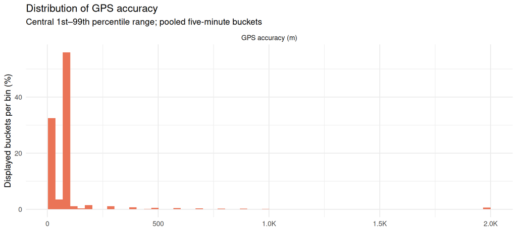

```r
distribution_histograms %>%
  filter(data_stream == "GPS") %>%
  ggplot(aes(x = bin_midpoint, weight = buckets)) +
  geom_histogram(
    aes(y = after_stat(100 * count / ave(count, PANEL, FUN = sum))),
    bins = cfg$histogram_bins,
    fill = viridisLite::viridis(1, option = "C", begin = 0.65)
  ) +
  facet_wrap(vars(panel_label), scales = "free") +
  scale_x_continuous(labels = scales::label_number(scale_cut = scales::cut_short_scale())) +
  labs(
    title = "Distribution of GPS accuracy",
    subtitle = "Central 1st–99th percentile range; pooled five-minute buckets",
    x = NULL, y = "Displayed buckets per bin (%)"
  )
```

## Environmental distributions

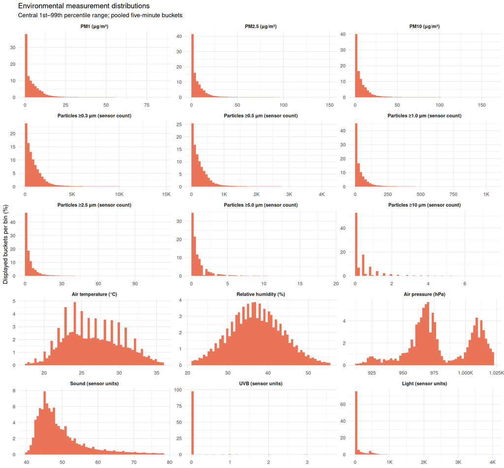

```r
distribution_histograms %>%
  filter(data_stream == "Environment") %>%
  ggplot(aes(x = bin_midpoint, weight = buckets)) +
  geom_histogram(
    aes(y = after_stat(100 * count / ave(count, PANEL, FUN = sum))),
    bins = cfg$histogram_bins,
    fill = viridisLite::viridis(1, option = "C", begin = 0.65)
  ) +
  facet_wrap(vars(panel_label), scales = "free", ncol = 3) +
  scale_x_continuous(labels = scales::label_number(scale_cut = scales::cut_short_scale())) +
  labs(
    title = "Environmental measurement distributions",
    subtitle = "Central 1st–99th percentile range; pooled five-minute buckets",
    x = NULL, y = "Displayed buckets per bin (%)"
  ) +
  theme(strip.text = element_text(face = "bold"))
```

## High-frequency smartwatch distributions

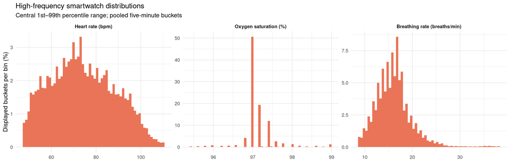

```r
distribution_histograms %>%
  filter(data_stream == "Smartwatch high frequency") %>%
  ggplot(aes(x = bin_midpoint, weight = buckets)) +
  geom_histogram(
    aes(y = after_stat(100 * count / ave(count, PANEL, FUN = sum))),
    bins = cfg$histogram_bins,
    fill = viridisLite::viridis(1, option = "C", begin = 0.65)
  ) +
  facet_wrap(vars(panel_label), scales = "free", ncol = 3) +
  scale_x_continuous(labels = scales::label_number(scale_cut = scales::cut_short_scale())) +
  labs(
    title = "High-frequency smartwatch distributions",
    subtitle = "Central 1st–99th percentile range; pooled five-minute buckets",
    x = NULL, y = "Displayed buckets per bin (%)"
  ) +
  theme(strip.text = element_text(face = "bold"))
```

### Sleep-state presence

Each state code (0–4) counts once per bucket when present. Bars are not exclusive: one bucket may contain several states. Clinical stage labels are not assigned.

```r
tibble(
  summary = c("Buckets with at least one sleep state", "Buckets containing multiple sleep states"),
  observed_5min_buckets = c(sleep_buckets_with_state, sleep_buckets_with_multiple_states),
  percent_of_sleep_state_buckets = c(
    100,
    100 * sleep_buckets_with_multiple_states / sleep_buckets_with_state
  )
) %>%
  mutate(percent_of_sleep_state_buckets = round(percent_of_sleep_state_buckets, 1)) %>%
  knitr::kable(
    format = "pipe", big.mark = ",",
    col.names = c("Summary", "Observed 5-minute buckets", "Sleep-state buckets (%)"),
    caption = "Availability and within-bucket multiplicity of sleep-state codes"
  )
```

Availability and within-bucket multiplicity of sleep-state codes

| Summary | Observed 5-minute buckets | Sleep-state buckets (%) |
| --- | --- | --- |
| Buckets with at least one sleep state | 288427 | 100.0 |
| Buckets containing multiple sleep states | 260724 | 90.4 |

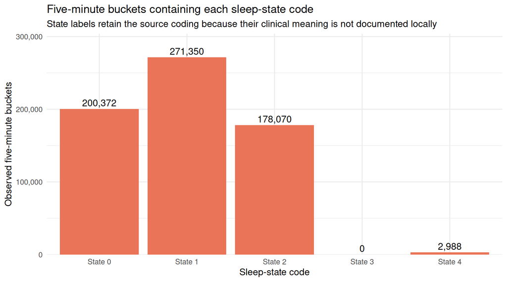

```r
sleep_state_summary %>%
  ggplot(aes(x = state, y = observed_5min_buckets)) +
  geom_col(fill = viridisLite::viridis(1, option = "C", begin = 0.65)) +
  geom_text(
    aes(label = scales::label_number(big.mark = ",", accuracy = 1)(observed_5min_buckets)),
    vjust = -0.4
  ) +
  scale_y_continuous(
    labels = scales::label_number(big.mark = ","),
    expand = expansion(mult = c(0, 0.12))
  ) +
  labs(
    title = "Five-minute buckets containing each sleep-state code",
    subtitle = "State labels retain the source coding because their clinical meaning is not documented locally",
    x = "Sleep-state code", y = "Observed five-minute buckets"
  )
```

## Low-frequency smartwatch distributions

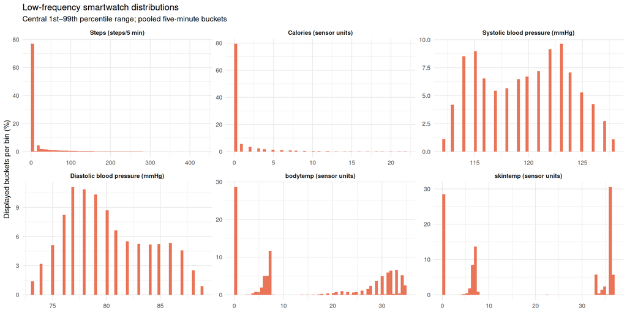

```r
distribution_histograms %>%
  filter(data_stream == "Smartwatch low frequency") %>%
  ggplot(aes(x = bin_midpoint, weight = buckets)) +
  geom_histogram(
    aes(y = after_stat(100 * count / ave(count, PANEL, FUN = sum))),
    bins = cfg$histogram_bins,
    fill = viridisLite::viridis(1, option = "C", begin = 0.65)
  ) +
  facet_wrap(vars(panel_label), scales = "free", ncol = 3) +
  scale_x_continuous(labels = scales::label_number(scale_cut = scales::cut_short_scale())) +
  labs(
    title = "Low-frequency smartwatch distributions",
    subtitle = "Central 1st–99th percentile range; pooled five-minute buckets",
    x = NULL, y = "Displayed buckets per bin (%)"
  ) +
  theme(strip.text = element_text(face = "bold"))
```

## Interpretation boundaries

Distributions are descriptive, not participant-balanced estimates. Repeated buckets are dependent, and extreme values are not automatically invalid.